# Assignment-Online Retail Analytics

```r
Online_Retail<-read.csv("./Online_Retail.csv")
```

**1. Breakdown of the number of transactions by countries in both percentage and count, and showing the countries accounting for more than 1% of the total transactions:**

```r
trans_countries<-Online_Retail %>% group_by(Country) %>% summarise(cnt = n()) %>% mutate(perc =round((cnt/sum(cnt))*100,5)) %>% filter(perc>1)
head(trans_countries)
```

| Country | cnt | perc |
| --- | --- | --- |
| EIRE | 8196 | 1.51243 |
| France | 8557 | 1.57905 |
| Germany | 9495 | 1.75214 |
| United Kingdom | 495478 | 91.43196 |

```r
NA
```

**2. Creating a new variable TransactionValue and adding it to the dataframe:**

```r
TransactionValue<-Online_Retail$Quantity*Online_Retail$UnitPrice

#creating a dataframe and adding TransactionValue to it

Online_Retail_new<-data.frame(InvoiceNo=Online_Retail$InvoiceNo,StockCode= Online_Retail$StockCode,Description=Online_Retail$Description,Quantity=Online_Retail$Quantity, InvoiceDate=Online_Retail$InvoiceDate,UnitPrice=Online_Retail$UnitPrice, CustomerID=Online_Retail$CustomerID,Country=Online_Retail$Country,  TransactionValue=TransactionValue)

head(Online_Retail_new)
```

|  | InvoiceNo | StockCode | Description | Quantity | InvoiceDate | UnitPrice | CustomerID | Country | TransactionValue |
| --- | --- | --- | --- | --- | --- | --- | --- | --- | --- |
| 1 | 536365 | 85123A | WHITE HANGING HEART T-LIGHT HOLDER | 6 | 12/1/2010 8:26 | 2.55 | 17850 | United Kingdom | 15.30 |
| 2 | 536365 | 71053 | WHITE METAL LANTERN | 6 | 12/1/2010 8:26 | 3.39 | 17850 | United Kingdom | 20.34 |
| 3 | 536365 | 84406B | CREAM CUPID HEARTS COAT HANGER | 8 | 12/1/2010 8:26 | 2.75 | 17850 | United Kingdom | 22.00 |
| 4 | 536365 | 84029G | KNITTED UNION FLAG HOT WATER BOTTLE | 6 | 12/1/2010 8:26 | 3.39 | 17850 | United Kingdom | 20.34 |
| 5 | 536365 | 84029E | RED WOOLLY HOTTIE WHITE HEART. | 6 | 12/1/2010 8:26 | 3.39 | 17850 | United Kingdom | 20.34 |
| 6 | 536365 | 22752 | SET 7 BABUSHKA NESTING BOXES | 2 | 12/1/2010 8:26 | 7.65 | 17850 | United Kingdom | 15.30 |

```r
NA
```

```r
Trans_value_countries<- Online_Retail_new %>% group_by(Country) %>% summarise(sum_TransactionValue = sum(TransactionValue)) %>% filter(sum_TransactionValue>130000)

head(Trans_value_countries)
```

| Country | sum_TransactionValue |
| --- | --- |
| Australia | 137077.3 |
| EIRE | 263276.8 |
| France | 197403.9 |
| Germany | 221698.2 |
| Netherlands | 284661.5 |
| United Kingdom | 8187806.4 |

```r
NA
```

**4. Optional question**

```r
Online_Retail_new$Invoice_Day_Week= weekdays(Online_Retail$New_Invoice_Date)
```

[output not shown]

**4(a). Percentage of transactions (by numbers) by days of the week**

| Invoice_Day_Week | count | perc |
| --- | --- | --- |
| Friday | 82193 | 15.16731 |
| Monday | 95111 | 17.55110 |
| Sunday | 64375 | 11.87930 |
| Thursday | 103857 | 19.16503 |
| Tuesday | 101808 | 18.78692 |
| Wednesday | 94565 | 17.45035 |

**4(b). Percentage of transactions (by transaction volume) by days of the week**

| Invoice_Day_Week | Total | percentage |
| --- | --- | --- |
| Friday | 1540610.8 | 15.804787 |
| Monday | 1588609.4 | 16.297194 |
| Sunday | 805678.9 | 8.265282 |
| Thursday | 2112519.0 | 21.671867 |
| Tuesday | 1966182.8 | 20.170636 |
| Wednesday | 1734147.0 | 17.790232 |

**4(c). Percentage of transactions (by transaction volume) by month of the year**

| New_Invoice_Month | Total | percentage |
| --- | --- | --- |
| 1 | 560000.3 | 5.744919 |
| 2 | 498062.6 | 5.109515 |
| 3 | 683267.1 | 7.009487 |
| 4 | 493207.1 | 5.059703 |
| 5 | 723333.5 | 7.420519 |
| 6 | 691123.1 | 7.090080 |

**4(d). The date with the highest number of transactions from Australia**

| New_Invoice_Date | count |
| --- | --- |
| 2011-06-15 | 139 |
| 2011-07-19 | 137 |
| 2011-08-18 | 97 |
| 2011-03-03 | 84 |
| 2011-10-05 | 82 |
| 2011-05-17 | 73 |

**5. Histogram of transaction Values from Germany**

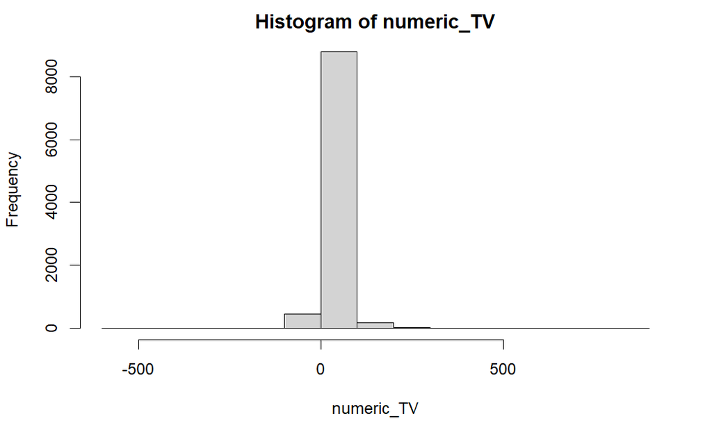

**6. Identifying the customer with highest number of transactions and finding the most valuable customer**

```r
cust_count<-Online_Retail_new %>% group_by(CustomerID) %>% summarise(cntt = n()) %>% arrange(desc(cntt))
head(cust_count)

#Customer 17841 has the highest number of transactions.
```

[output not shown]

```r
cust_sum<-Online_Retail_new %>% group_by(CustomerID) %>% summarise(sum_cnt =sum(TransactionValue)) %>% arrange(desc(sum_cnt))

head(cust_sum)

#Customer 14646 is the most valuable
```

[output not shown]

**7. Percentage of missing values for each variable in the dataset**

```r
missing_values<- (colMeans(is.na(Online_Retail_new))*100)

missing_values
```

[output not shown]

**8. Number of transactions with missing CustomerID records by countries**

```r
missing<-Online_Retail_new %>% filter(is.na(CustomerID)) %>% group_by(Country) %>% summarise(count_by_countries = n())

head(missing)
```

[output not shown]

**9. On average, how often the costumers comeback to the website for their next shopping?**

```r
mean(difference_days$days)
```

```
Time difference of 38.4875 days
```

**10. Return rate for the French customers**

```r
return_rate <- Online_Retail_new %>% filter(Country=='France')
cancelled_customers <- nrow(subset(return_rate,TransactionValue<0))
View(cancelled_customers)

return_rate_french_cust=(cancelled_customers/8556)

head(return_rate_french_cust)
```

[output not shown]

**11. Product that has generated the highest Revenue for the retailer**

```r
item_sum<-Online_Retail_new %>% group_by(Description) %>% summarise(sum_cnt = sum(TransactionValue)) %>% arrange(desc(sum_cnt))
head(item_sum)

#DOTCOM POSTAGE generates highest revenue for the retailer
```

[output not shown]

**12. Unique customers in the dataset**

```r
unique_cust<- Online_Retail_new %>% distinct(CustomerID) %>% summarise(ncount = n())
head(unique_cust)
 #There are 4373 unique customers in the dataset
```

[output not shown]